# compromis

Alexandre CONANEC

31 mai 2018

```r
library(mfe)
#import data
data <- as.matrix(read.csv('mfe/data/big_simulation3.csv', header = T, sep = ';', dec = ',')[,-26])
initiation <- as.factor(as.vector(read.csv('mfe/data/big_simulation3.csv', header = T, sep = ';', dec = ',')[,26]))
CDC <- read.csv('mfe/data/cahier_des_charges2.csv', header = T, sep = ';', dec = ',')
CDC$objectif <- as.factor(CDC$objectif)
CDC
```

```
##    cluster        seuil coef_agreg objectif
## 1      EI1 -112.7873801      0.330     <NA>
## 2      EI2   -0.5767531      0.330     <NA>
## 3      EI3    3.1563202     -0.330     <NA>
## 4      QC1   -6.0521740      0.100     <NA>
## 5      QC2           NA      0.000     <NA>
## 6      QC3    4.1293977     -0.200     <NA>
## 7      QC4    3.5575087     -0.200     <NA>
## 8      QC5  -71.3992820      0.150     <NA>
## 9      QC6   -1.8445322      0.200     <NA>
## 10     QC7   -3.2022488      0.150     <NA>
## 11     QN1           NA     -0.150        1
## 12     QN2           NA     -0.150        1
## 13     QN3           NA      0.250        1
## 14     QN4           NA      0.050        1
## 15     QN5           NA      0.050        1
## 16     QN6           NA     -0.250        1
## 17     QN7           NA      0.100        1
## 18     QS1           NA      0.425        2
## 19     QS2           NA      0.150        2
## 20     QS3           NA     -0.025        2
## 21     QS4           NA     -0.125        2
## 22     QS5           NA     -0.050        2
## 23     QS6           NA     -0.050        2
## 24     QS7           NA      0.175        2
```

```r
objectifs <- list()
for (k in levels(CDC$objectif)){

  objectifs[[k]]$index <- which(CDC$objectif == k)
  objectifs[[k]]$w <- CDC$coef_agreg[which(CDC$objectif == k)]
  names(objectifs)[as.numeric(k)] <- paste(unlist(strsplit(as.character(CDC$cluster[which(CDC$objectif == k)][1]), split = ''))[-3], collapse = '')

}


constraint <- list(seuil_plus = CDC$seuil[which(! is.na(CDC$seuil) & CDC$seuil > 0)],
                   seuil_minus = CDC$seuil[which(! is.na(CDC$seuil) & CDC$seuil < 0)],
                   index_plus = which(! is.na(CDC$seuil) & CDC$seuil > 0),
                   index_minus = which(! is.na(CDC$seuil) & CDC$seuil < 0))



res <- bovCDC(X = data[,-1],
              objectifs = objectifs,
              constraint = constraint,
              scale = TRUE)

delete_by_threshold <- which(!res$constraint_respected)
res <- res[-delete_by_threshold, 1:2]
```

A cette étape on vient de supprimer 12 individus qui ne respectait pas les conditions. Mettre des seuils un peu plus severe ou pour QN et QS pourrait augmenter la selection.

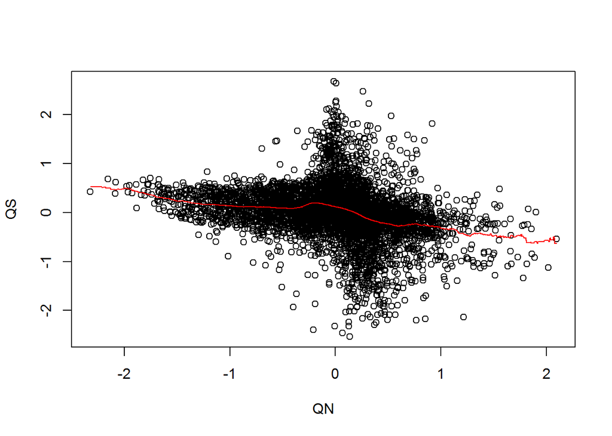

```r
plot(res)
lines(ksmooth(x = res[,1], y = res[,2]), col = 'red')
```

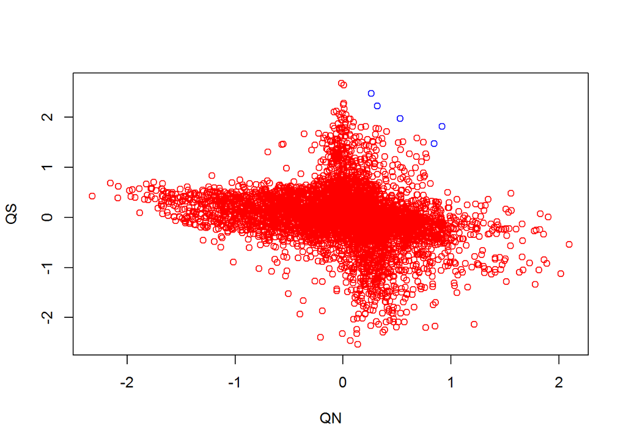

```r
X_scale <- scale(data)
X_decision <- pareto_finding (X = X_scale, Y = res, method = 'target', target = c(2,3), n = 5, plot = TRUE)
```

Par rapport aux derniers resultats, on remarque que QS et QN sont lègerement negativement correles. Bon signe pour notre étude même si c’est pas flagrant et que les points du milieu sont un peu bizarres (cf l’explication plus bas)

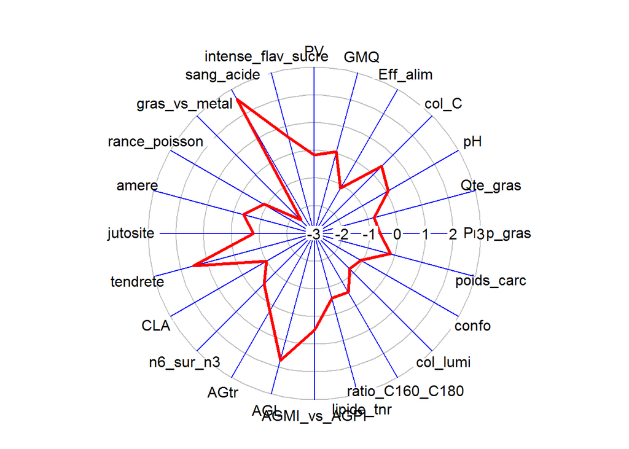

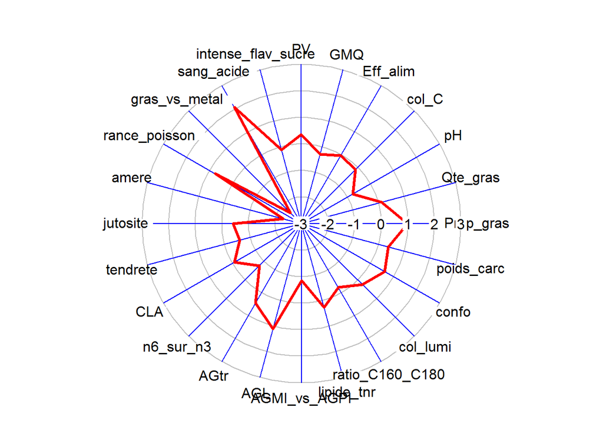

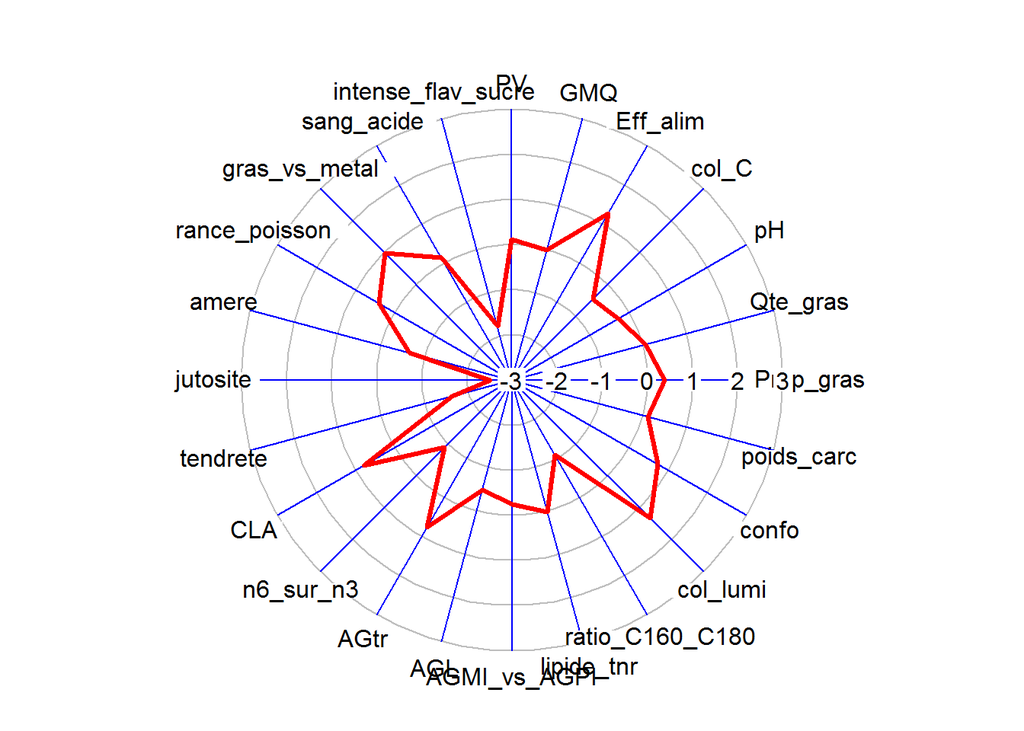

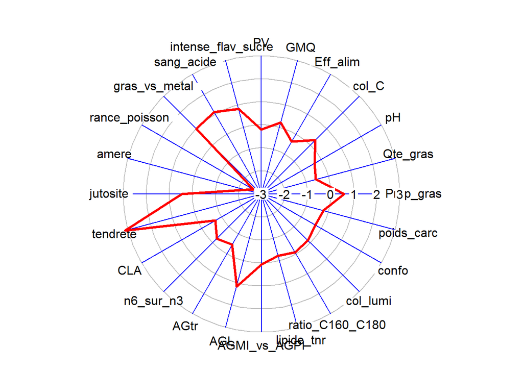

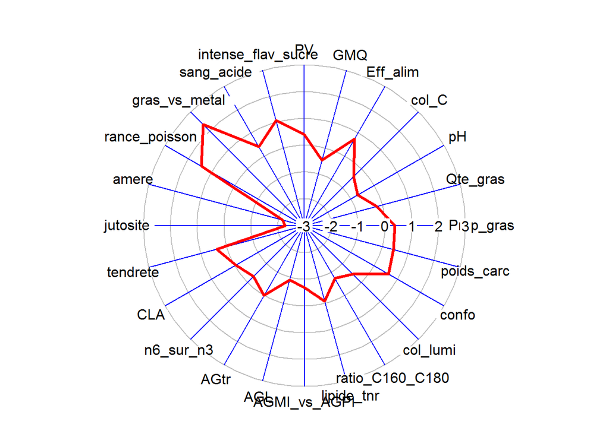

```r
for (i in 1:nrow(X_decision$X)){

  cow <- as.matrix(as.data.frame(t(X_decision$X[i,]))[-1])
  class(cow) <- 'cow'
  plot(cow, choice = 'radar_diag',  radial.lim = c(-3,3))
}
```

Ici on retrouve le profil de nos meilleurs compromis.

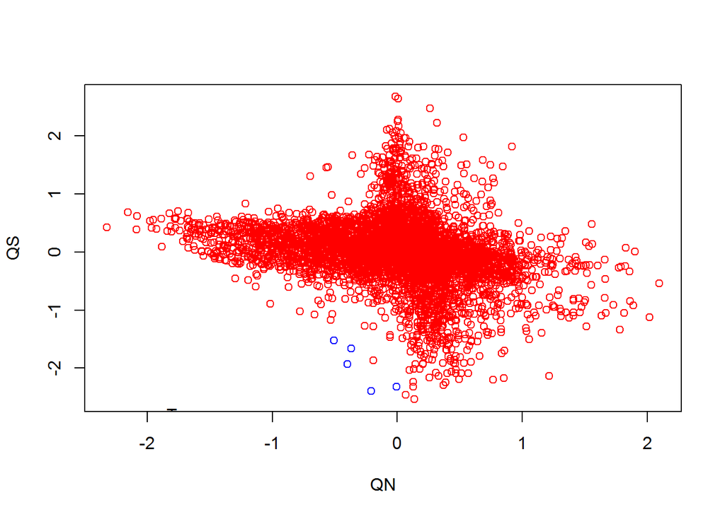

```r
X_scale <- scale(data)
X_decision <- pareto_finding (X = X_scale, Y = res, method = 'target', target = c(-2,-3), n = 5, plot = TRUE)
```

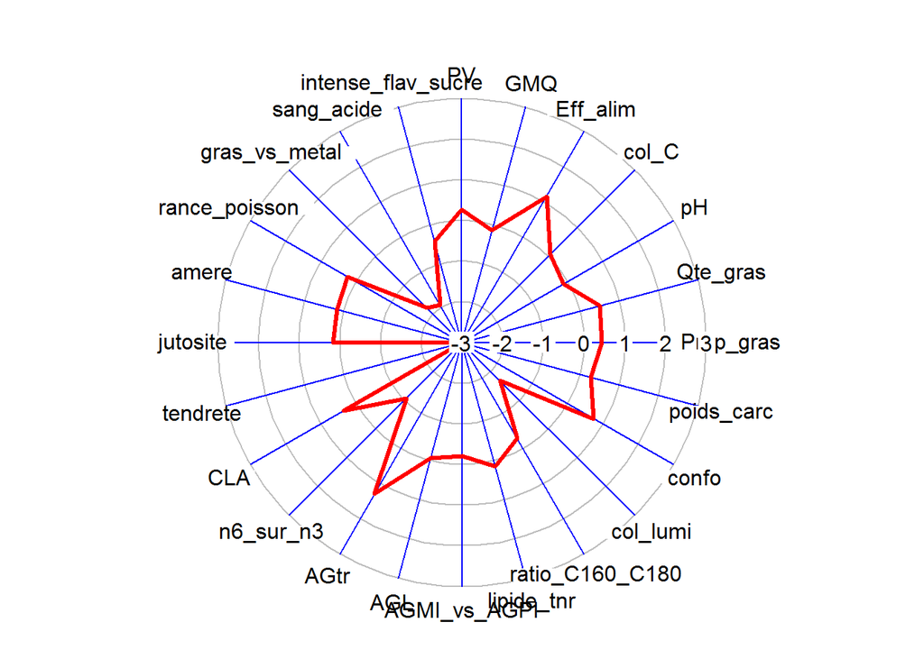

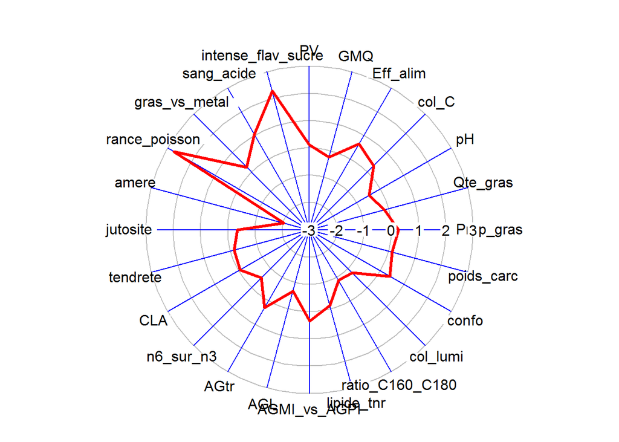

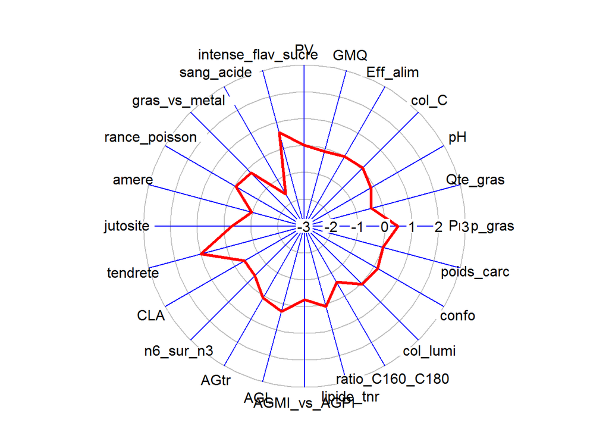

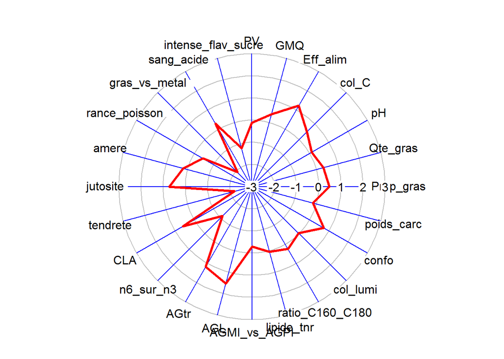

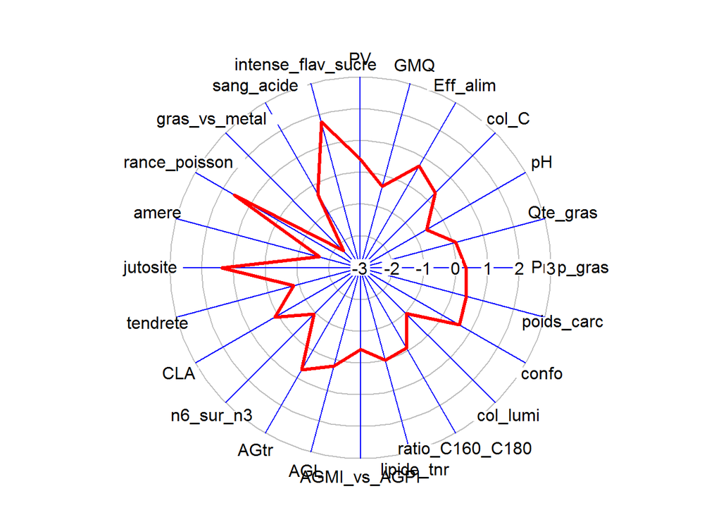

```r
for (i in 1:nrow(X_decision$X)){

  cow <- as.matrix(as.data.frame(t(X_decision$X[i,]))[-1])
  class(cow) <- 'cow'
  plot(cow, choice = 'radar_diag',  radial.lim = c(-3,3))
}
```

Et ici celui des pire compromis

Je regarde maintenant quels sont les ‘initiateurs’ des points qui semblent disperses au milieu, car je soupçonne que ce soit majoritairement des QS. En effet je pense que la seule variabilité importante est donnée par des valeurs initiées au départ et non par les modeles.

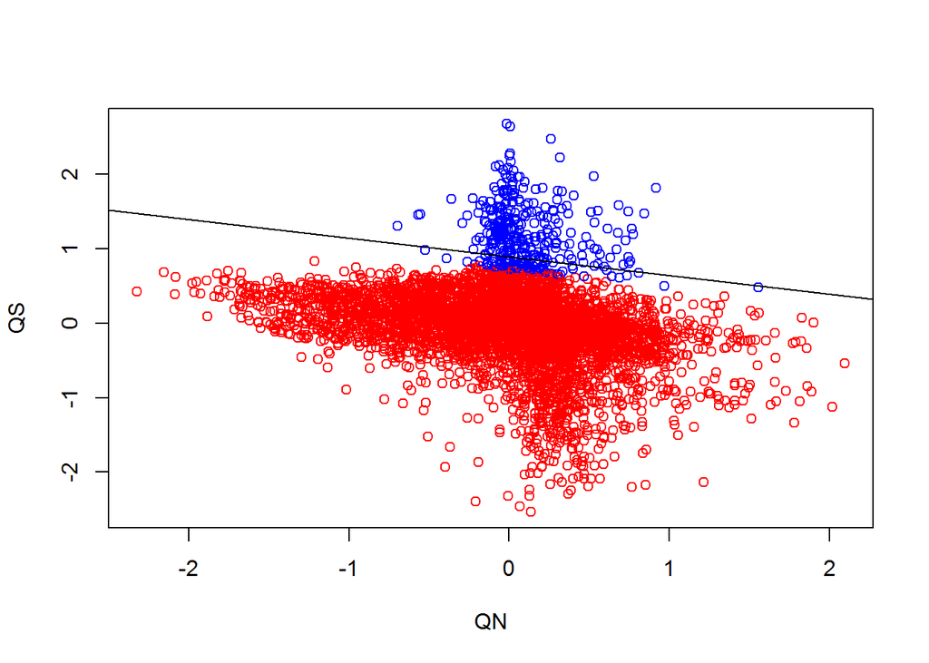

```r
X_decision <- pareto_finding (X = X_scale, Y = res, method = 'weight_aggregation', w = c(0.2, 0.8), n = 350, plot = TRUE)
```

```r
ind_sel <- as.numeric(rownames(X_decision$Y))
ind_sel_corrected <- c()
for (i in 1:length(ind_sel)){

  correction <- length(which(ind_sel[i] > delete_by_threshold))
  ind_sel_corrected[i] <- ind_sel[i] + correction
}

table(initiation[ind_sel_corrected])
```

```
##
##  EI  QC  QN  QS
##  27   3   1 317
```

Hypothese verifiée! On observe qu’une large majorité des valeurs (317) en bleu ont été initiées par QS (cad que l’on a fixé les indicateurs de QS et calculé les autres avec les modèles). Cela semble néanmoins, moins flagrant qu’avec les derniers résultats. Cela s’explique par le fait que seul la jutosité a un mauvais modèle (et predit en conséquence des valeurs moyennes) mais le poids accordé est faible.